# Sentiment Analysis

Lucia Michielin

2024-05-24

- A form of supervised learning that assigns a polarity score to textual data.
- Existing tools classify text based on a lexicon or a set of rules; aspects, or features of the text; or though deep learning.
- Can analyse text at various levels (e.g. word/aspect, sentence, paragraph, document)
- Designed to parse opinionated data
- Some linguistic limitations include sarcasm, humor, slang, and connotation

## Research questions/aim

1. Can we use sentiment analysis algorithms to automatically assess the polarity (+/-)trends in unstructured data (reviews of whiskies bottles)
2. How this polarities values compare with general rates
3. Which other sentiments can be detected by sentiments analysis algorithms
4. How accurate are these algorithms and how can we use them

## Install andLoad the packages that we need

Before we start playing around we need to install the needed packages and load all the packages we need for the session

```r
#install.packages("syuzhet") # Sentiment Analysis package
#install.packages("tidytext") # Text Analysis
#install.packages("Polychrome") # Palette
#install.packages("wordcloud")# wordcloud
#install.packages("quanteda.sentiment") # Sentiment Analysis Package within Quanteda
```

[output not shown]

## Load our data

The first thing to do is to import the dataset we are going to use. In our case that is the full dataset of whiskies reviews we scrape this morning. The version we obtain this morning is a reduce sample but let’s play with the full sample that was extracted by letting this morning code running for a couple of days

```r
WhiskyReview <- read_csv("export/ReviewWithDistilleriesInfoV2.csv")
summary(WhiskyReview)
```

```
##   Distillery          Location            Region             Founded
##  Length:845         Length:845         Length:845         Min.   :1763
##  Class :character   Class :character   Class :character   1st Qu.:1821
##  Mode  :character   Mode  :character   Mode  :character   Median :1836
##                                                           Mean   :1855
##                                                           3rd Qu.:1886
##                                                           Max.   :2005
##
##     Owner                AVB         BottleName          Reviews
##  Length:845         Min.   :40.00   Length:845         Length:845
##  Class :character   1st Qu.:43.00   Class :character   Class :character
##  Mode  :character   Median :46.00   Mode  :character   Mode  :character
##                     Mean   :46.97
##                     3rd Qu.:51.10
##                     Max.   :65.80
##                     NA's   :5
##       Rate
##  Min.   :72.00
##  1st Qu.:81.00
##  Median :83.00
##  Mean   :82.59
##  3rd Qu.:85.00
##  Max.   :87.00
##  NA's   :340
```

## Syuzhet

the syuzhet a sentiment analysis package, written by Matthew Jockers. The term ‘syuzhet’ is Russian (сюже́т) and translates roughly as ‘plot’, or the order in which events in the narrative are presented to the reader, which may be different than the actual time sequence of events (the ‘fabula’). The syuzhet package similarly considers sentiment analysis in a time-series-friendly manner, allowing you to explore the developing sentiment in a text across the pages (from https://programminghistorian.org/en/lessons/sentiment-analysis-syuzhet).

More information on the details of the package can be found here https://cran.r-project.org/web/packages/syuzhet/syuzhet.pdf

We do not have time to go into the detail of how the algorithms works but if you are going to use it for research make sure to read the details of how the methods works

### Obtain the Sentiment Score for our Review field

```r
SentimentScoresS <- get_nrc_sentiment(WhiskyReview$Reviews)


summary(SentimentScoresS)
```

```
##      anger         anticipation      disgust            fear
##  Min.   : 0.000   Min.   :  0.0   Min.   : 0.000   Min.   : 0.000
##  1st Qu.: 1.000   1st Qu.:  5.0   1st Qu.: 2.000   1st Qu.: 1.000
##  Median : 3.000   Median : 10.0   Median : 4.000   Median : 3.000
##  Mean   : 6.518   Mean   : 15.8   Mean   : 6.709   Mean   : 6.957
##  3rd Qu.: 8.000   3rd Qu.: 19.0   3rd Qu.: 8.000   3rd Qu.: 8.000
##  Max.   :84.000   Max.   :120.0   Max.   :73.000   Max.   :97.000
##       joy            sadness          surprise          trust
##  Min.   :  0.00   Min.   : 0.000   Min.   : 0.000   Min.   :  0.00
##  1st Qu.:  5.00   1st Qu.: 2.000   1st Qu.: 3.000   1st Qu.:  6.00
##  Median :  9.00   Median : 4.000   Median : 6.000   Median : 11.00
##  Mean   : 15.24   Mean   : 7.611   Mean   : 9.707   Mean   : 18.39
##  3rd Qu.: 19.00   3rd Qu.: 9.000   3rd Qu.:12.000   3rd Qu.: 23.00
##  Max.   :128.00   Max.   :88.000   Max.   :83.000   Max.   :153.00
##     negative         positive
##  Min.   :  0.00   Min.   :  0.00
##  1st Qu.:  5.00   1st Qu.: 11.00
##  Median : 10.00   Median : 23.00
##  Mean   : 18.39   Mean   : 37.66
##  3rd Qu.: 21.00   3rd Qu.: 44.00
##  Max.   :212.00   Max.   :326.00
```

### Visualise these data

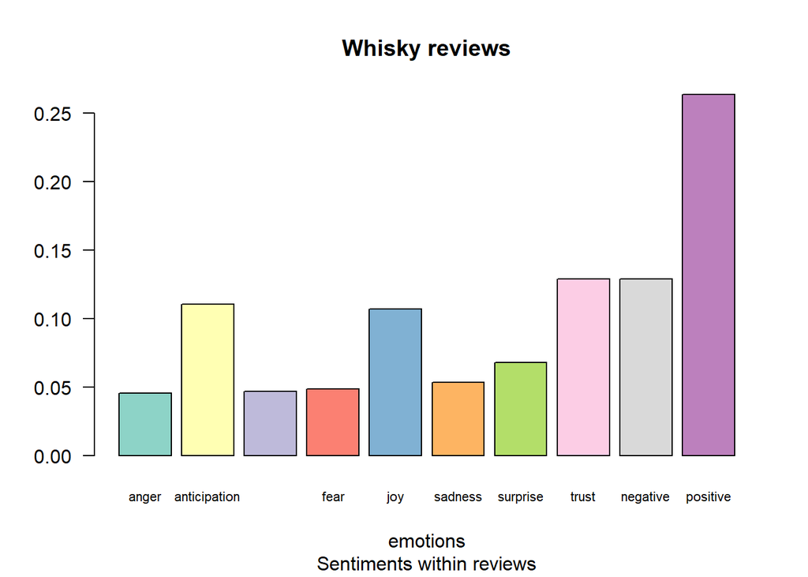

```r
barplot(
  colSums(prop.table(SentimentScoresS[, 1:10])),
  space = 0.2,
  horiz = FALSE,
  las = 1,
  cex.names = 0.7,
  col = brewer.pal(n = 10, name = "Set3"),
  main = "Whisky reviews",
  sub = "Sentiments within reviews",
  xlab="emotions", ylab = NULL)
```

### Discussion

What do you think we are looking at? How do you think the different sentiments are extracted?

### Explore the results

To get a better insight of what is inside let’s merge back the new dataset with the original one

```r
FullSentiment<-cbind(WhiskyReview,SentimentScoresS)
```

To be able to properly explore the data we need to rework the dataset from a “wide” format to a “long” format

```r
# Reshape the data from wide to long format, preserving other columns
long_dataWhisky <- gather(data = FullSentiment,
                    key = "sentiment", #how do I want to rename the new column containing headers of the columns
                    value = "value", # how to call the values extracted
                    -(Distillery:Rate))# which columns do not need to be gatehered
```

At this stage because we want to look at proportion of different sentiment let’s remove positive/negative

```r
long_dataWhisky_Sentiments<-filter(long_dataWhisky,sentiment!="positive" & sentiment!="negative")
```

Now we can explore it better using ggplot First by Region

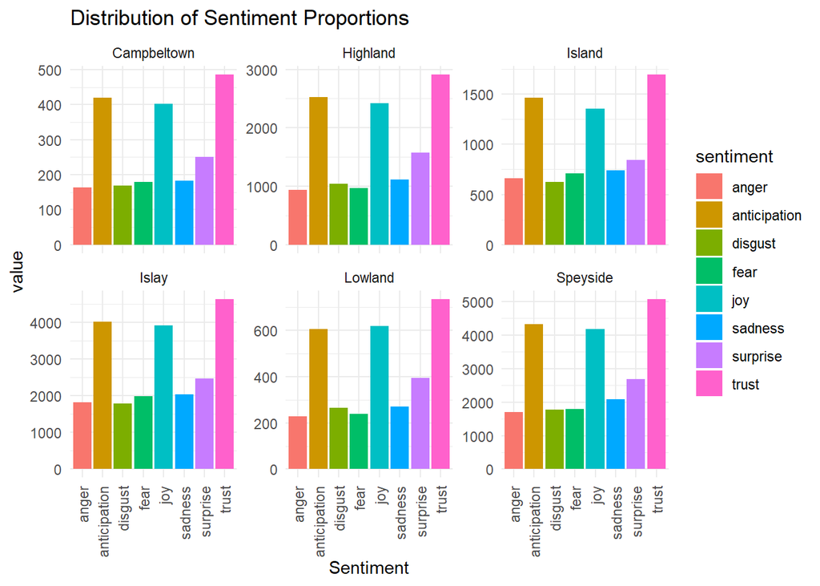

```r
ggplot(long_dataWhisky_Sentiments, aes(x = sentiment, y=value, fill=sentiment)) + #Dataset, x, y and colour
  geom_bar(stat = "identity") + #type of graph
  labs(title = "Distribution of Sentiment Proportions",
       x = "Sentiment", y = "value") + # rename labels
  theme_minimal()+ #Use a minimal theme
  theme(axis.text.x = element_text(angle = 90, vjust = 0.5, hjust=1))+ #rotate the labels of 90 degree
  facet_wrap(~Region, scales = "free_y") #subset by region and free the y axis
```

###Exercise one

Plot it subdividing by ownership of the distilleries.

Does the result change compared to the previous graph?

### Explore the words associated with each sentiment

Because it is a quite big dataset we will do it on a subset so we look only at the Lowland sample

First subset the dataset to get only the Lowland whiskies reviews

```r
Lowland<-subset(WhiskyReview, Region=="Lowland" )
```

Then we need to tokenise the new dataset

```r
words_list <- Lowland %>%
  unnest_tokens(word, Reviews) %>%
  filter(nchar(word) >3 & !str_detect(word, "^[0-9]+$")) %>%
  pull(word)
```

Now we can re run the nrc sentiment function

```r
Lowlandsentiment_scoresT <- get_nrc_sentiment(words_list)
```

You can see that because we are now running the function on a tokenised object it is much slower even if we are working on a much smaller sample.

First let’s focus on the words associated with joy

```r
JoyWords <- words_list[Lowlandsentiment_scoresT$joy> 0]
head(JoyWords)
```

```
## [1] "sweet"      "delightful" "sweet"      "lovely"     "saint"
## [6] "successful"
```

Let’s see what are the most recurring ones

```r
JoyWordsOrder <- sort(table(unlist(JoyWords)), decreasing = TRUE)
head(JoyWordsOrder, n = 12)
```

```
##
##     sweet      good     young  pleasant chocolate     green     found     white
##       182       108        47        45        41        36        31        25
##      hero      love     cream     clean
##        23        23        21        20
```

Convert the table to a data frame and rename the variables word and frequency

```r
JoyDF <- as.data.frame(JoyWordsOrder)
names(JoyDF) <- c("word", "frequency")
```

Because we have a lot words we want a bigger colour palette. Glasbey is a colour palette from the Polychrome Palette

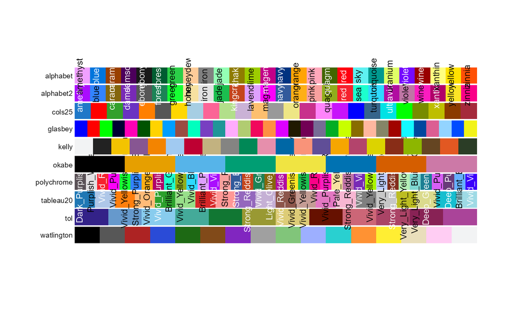

Polychrome Palette

```r
color_palette <- glasbey.colors(32)
```

Now we can print the most recurring words of Joy as a wordcloud

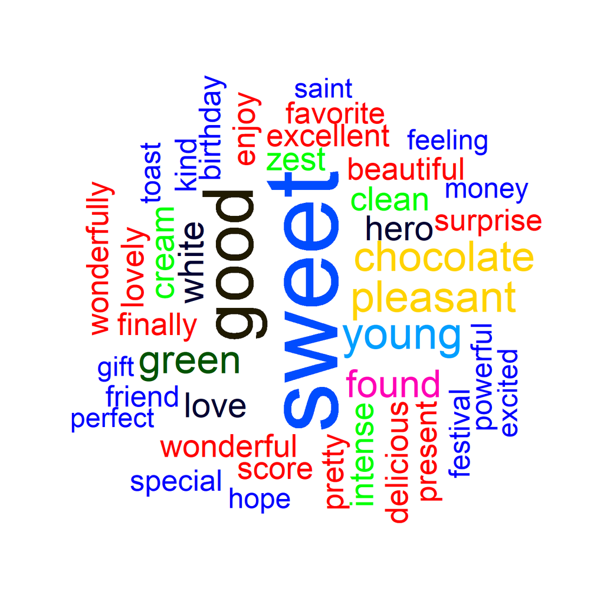

```r
wordcloud(words = JoyDF$word,
          freq = JoyDF$frequency,
          scale=c(8,2),# rage of font sizes
          colors=color_palette,
          random.order=FALSE, rot.per=0.35,
          max.words =100)
```

Or if I want to plot frequencies

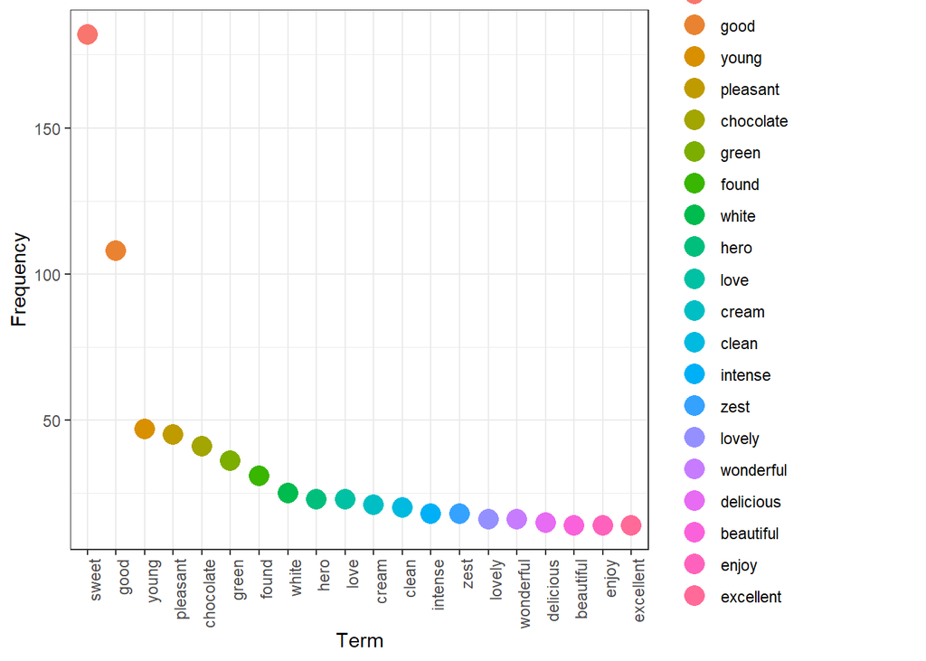

```r
First20JoyDF<-JoyDF%>%
  arrange(desc(frequency))%>%
  head(20)
#aes(x = reorder(word,-frequency), y = frequency))
ggplot(First20JoyDF, aes(x = reorder(word,-frequency), y = frequency, colour=reorder(word, -frequency))) + # Plotting with ggplot2
  geom_point(size=5) +
  theme_bw() +
  labs(x = "Term", y = "Frequency") +
  theme(axis.text.x=element_text(angle=90, hjust=1))
```

### Discussion

What is this telling about the words associate with Joy in our sample?

What about terms associated with disgust? Write your code below

### Positive and Negative words

So far we looked at specific sentiment but what about positive and negative feelings First we need to subset for only positive and negative

```r
long_dataWhisky_PN<-filter(long_dataWhisky,sentiment=="positive" | sentiment=="negative")
```

Now we can plot the Distribution of Sentiment Proportions

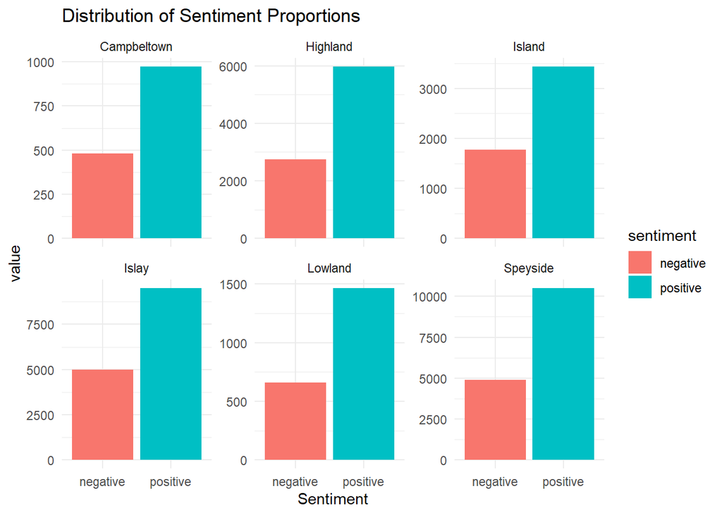

```r
ggplot(long_dataWhisky_PN, aes(x = sentiment, y=value, fill=sentiment)) +
  geom_bar(stat = "identity") +
  labs(title = "Distribution of Sentiment Proportions",
       x = "Sentiment", y = "value") +
  theme_minimal()+
  facet_wrap(~Region, scales = "free_y")
```

again not too easy to look at let’s use a pipe to create better proportions

```r
proportionsArea <- long_dataWhisky_PN %>%
  group_by(Region,sentiment)%>%
  summarise(count= sum(value))%>%
  mutate(Ratio=(round(count/sum(count),2)*100))
```

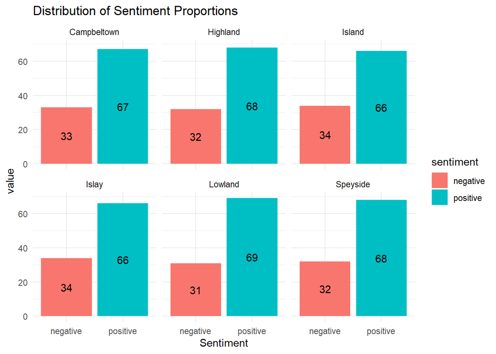

```r
ggplot(proportionsArea, aes(x = sentiment, y=Ratio, fill=sentiment)) +
  geom_bar(stat = "identity") +
  labs(title = "Distribution of Sentiment Proportions",
       x = "Sentiment", y = "value") +
  geom_text(aes(label = Ratio), position = position_stack(vjust = 0.5), color = "black") +
  theme_minimal()+
  facet_wrap(~Region)
```

This is only counting words or proportion that has a negative or positive association what if we try to use a different sentiment dictionary.

**NB** there is an incredible amount of dictionaries and sentiment analysis models out there some more refined than others so if you are using sentiment analysis for your research you always have to read the published article associated with the methods and identify the one that would better suit your research questions. Some are more advanced than other with some recent model than allows you to implement machine learning and Bayesian techniques into your processing but this is way beyond what we can cover in this 90 minutes if you are interested in that aspect you can have a look at this blog post https://www.r-bloggers.com/2016/01/sentiment-analysis-with-machine-learning-in-r/

That been said let’s have a look at a different library to do sentiment analysis i.e. the sentiment extension of the Quanteda package

## Quanteda

First we need to Tokenise our reviews with Quanteda (NB each text analysis package would output slightly differently so if you use the sentiment package of Quanteda you need to tokenise with Quanteda )

```r
ToksReviewsQuanteda <- WhiskyReview$Reviews %>%
  corpus() %>%
  tokens(
    what = "word",
    remove_punct = TRUE,
    remove_symbols = TRUE,
    remove_numbers = TRUE
  ) %>%
  tokens_remove(., pattern = stopwords("en"))

head(ToksReviewsQuanteda)
```

```
## Tokens consisting of 6 documents.
## text1 :
##  [1] "Day"       "KWM"       "Whisky"    "Advent"    "Calendar"  "Aberfeldy"
##  [7] "Year"      "Old"       "reviewed"  "though"    "many"      "years"
## [ ... and 890 more ]
##
## text2 :
##  [1] "believe"     "Aberfeldy's" "malt"        "whisky"      "goes"
##  [6] "Dewar's"     "line"        "blended"     "whiskies"    "thousand"
## [11] "different"   "Aberfeldy"
## [ ... and 1,584 more ]
##
## text3 :
##  [1] "I’ve"         "now"          "sufficiently" "analyzed"     "malt"
##  [6] "enough"       "worthy"       "least"        "separate"     "reviews"
## [11] "I’ve"         "distilled"
## [ ... and 801 more ]
##
## text4 :
##  [1] "know"     "now"      "liked"    "Aberlour" "A’Bunadh" "outset"
##  [7] "whisky"   "journey"  "began"    "earnest"  "early"    "years"
## [ ... and 11,940 more ]
##
## text5 :
##  [1] "oldie"      "Aberlour"   "750ml"      "bottle"     "released"
##  [6] "70s"        "last"       "century"    "hence"      "years"
## [11] "bottle"     "distillate"
## [ ... and 102 more ]
##
## text6 :
##  [1] "15yr"       "Sherry"     "Wood"       "Finish"     "Aberlour"
##  [6] "distillery" "Speyside"   "official"   "bottling"   "ABV"
## [11] "color"      "copper"
## [ ... and 101 more ]
```

The data dictionary that we are using has 4 categories, positive, negative and neg_positive and neg_negative https://quanteda.io/reference/data_dictionary_LSD2015.html

We subset the data dictionary for only the positive and negative words, so we can calculate polarity scores

```r
polarity(data_dictionary_LSD2015) <-
  list(pos = c("positive", "neg_negative"), neg = c("negative", "neg_positive"))
```

Now we can calculate the polarity of each text in toks, to get a sense of how positive vs negative each text is.

There are three way this can be done

### Sentiment Measures

**`sent_logit`:**

$$\log\left(\frac{\text{pos}}{\text{neg}}\right)$$

This measure represents the logarithm of the ratio of positive to negative features in a document. It’s also known as the log-odds ratio. This can be interpreted as:

- When $\text{pos} > \text{neg}$, the value will be positive, indicating a predominance of positive features.
- When $\text{pos} < \text{neg}$, the value will be negative, indicating a predominance of negative features.
- When $\text{pos} = \text{neg}$, the value will be zero, indicating an equal number of positive and negative features.

**`sent_abspropdiff`:**

$$\frac{\text{pos} - \text{neg}}{N}$$

This measure represents the absolute proportion difference between positive and negative features, normalized by the total number of all features in the document ($N$). Here:

This measure gives an idea of how much more (or less) positive features there are compared to negative ones, in relation to the total number of features.

- A positive value indicates more positive features.
- A negative value indicates more negative features.
- A value close to zero indicates a balance between positive and negative features.

**`sent_relpropdiff`:**

$$\frac{\text{pos} - \text{neg}}{\text{pos} + \text{neg}}$$

This measure represents the relative proportion difference between positive and negative features, normalized by the sum of positive and negative features. Here:

- $\text{pos} - \text{neg}$: This is the net sentiment, showing the difference between the number of positive and negative features.
- $\text{pos} + \text{neg}$: This is the total number of sentiment features (positive and negative).

This measure gives a relative sense of the balance between positive and negative features:

- A value of +1 indicates that all features are positive ($\text{neg} = 0$).
- A value of -1 indicates that all features are negative ($\text{pos} = 0$).
- A value of 0 indicates an equal number of positive and negative features.

**Summary:**

- `sent_logit` measures the log-odds ratio, which gives a logarithmic scale of the balance between positive and negative features. Values between -/+ infinite
- `sent_abspropdiff` measures the absolute difference between positive and negative features normalized by the total number of features, giving an absolute proportion difference. Values between -1 and +1
- `sent_relpropdiff` measures the relative difference between positive and negative features normalized by their sum, giving a relative proportion difference.Values between -1 and +1

```r
Polarity1 <- as.data.frame(textstat_polarity(ToksReviewsQuanteda, data_dictionary_LSD2015, fun = sent_logit))

head(Polarity1)
```

```
##   doc_id sentiment
## 1  text1 1.1895841
## 2  text2 1.0209033
## 3  text3 0.3467156
## 4  text4 0.9762152
## 5  text5 1.6863990
## 6  text6 0.7375989
```

This is the default one so we do not really have to specify the fun used but to completeness.

Now with **sent_abspropdiff**

```r
Polarity2 <- textstat_polarity(ToksReviewsQuanteda, data_dictionary_LSD2015,  fun = sent_abspropdiff)
head(Polarity2)
```

```
##   doc_id  sentiment
## 1  text1 0.07982262
## 2  text2 0.05952381
## 3  text3 0.02829028
## 4  text4 0.07333612
## 5  text5 0.09649123
## 6  text6 0.05309735
```

Now with **sent_relpropdiff**

```r
Polarity3 <- textstat_polarity(ToksReviewsQuanteda, data_dictionary_LSD2015,  fun = sent_relpropdiff)
head(Polarity3)
```

```
##   doc_id sentiment
## 1  text1 0.5373134
## 2  text2 0.4726368
## 3  text3 0.1729323
## 4  text4 0.4529473
## 5  text5 0.7333333
## 6  text6 0.3750000
```

Let’s compare our results

```r
summary(Polarity1$sentiment) #can go from -n +n
```

```
##    Min. 1st Qu.  Median    Mean 3rd Qu.    Max.
## -1.0986  0.7553  1.0726  1.0744  1.3695  3.4340
```

```r
summary(Polarity2$sentiment) #can go from -1 +1
```

```
##     Min.  1st Qu.   Median     Mean  3rd Qu.     Max.     NA's
## -0.20000  0.05315  0.07426  0.07614  0.09480  0.75000        1
```

```r
summary(Polarity3$sentiment) #can go from -1 +1
```

```
##    Min. 1st Qu.  Median    Mean 3rd Qu.    Max.    NA's
## -1.0000  0.3750  0.5000  0.4889  0.6190  1.0000       4
```

Let’s Plot Polarity 1

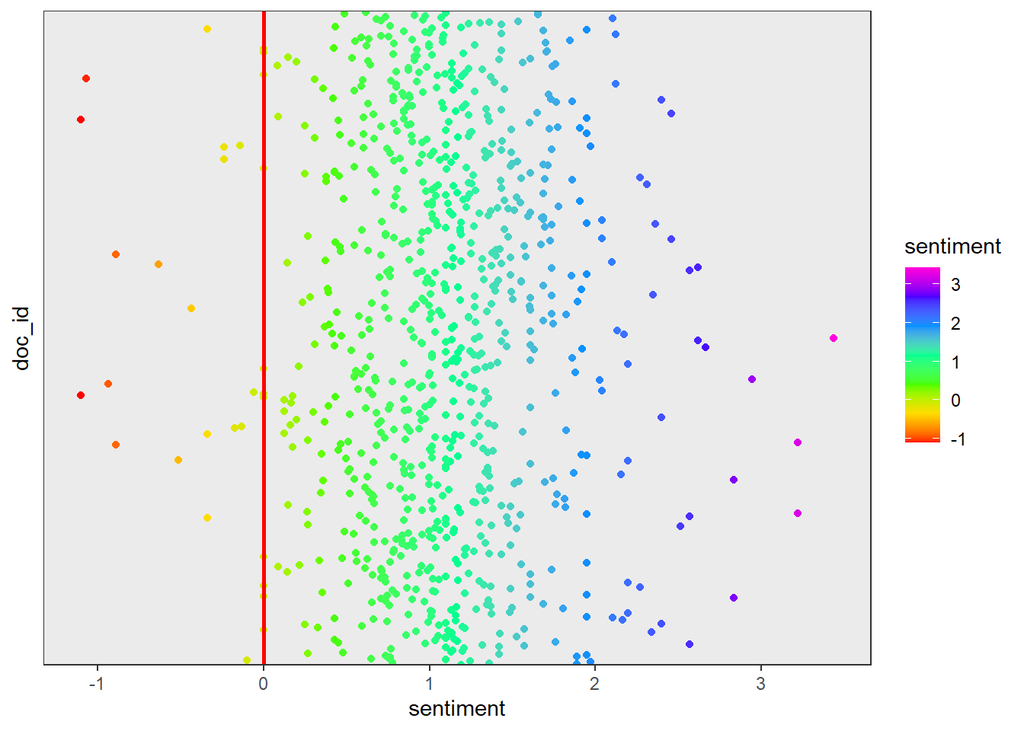

```r
ggplot(data = Polarity1, aes(x = sentiment, y = doc_id, colour=sentiment)) +
  geom_point()+
  theme_bw()+
  geom_vline(xintercept = 0, colour="red", size=1)+
  scale_colour_gradientn(colors=rainbow(7)) +
  theme(axis.text.y=element_blank(),
        axis.ticks.y=element_blank())#I removed the thick and labels of the y axis cause we don't really need to know which is which
```

### Exercise

How does it change for the other two methods? Write your code below

## Compare rate with polarity

Because we are collecting reviews of whisky we not only have the text of the review but also a rate that was associated with the bottle let’s see how the different methods of computing the polarity and these rate compare.

The first thing we need to do is to linearly transform the original -1+1 scales into 0-100

**NB** we cannot do this for the logarithmic option because it is not on a -1+1 scale

```r
transformedPol2 <- ((Polarity2$sentiment + 1)) * 50
transformedPol3 <- ((Polarity3$sentiment + 1)) * 50
```

We then create a new dataset containing the new calculated fields

```r
FullPolarity<-cbind(WhiskyReview,doc_id=Polarity1$doc_id,PolAbspropdiff=transformedPol2, PolRelpropdiff=transformedPol3)
```

Lets do the same for the Syuzet one  
First obtain the polarity

```r
FullSentiment <- FullSentiment %>%
  mutate(scaledPolarity =  ((positive - negative) / (positive +negative)))
```

Then scale it between 0-100

```r
FullPolarity$syuzhetPolarity <- ((FullSentiment$scaledPolarity + 1)) * 50
summary(FullPolarity$syuzhetPolarity)
```

```
##    Min. 1st Qu.  Median    Mean 3rd Qu.    Max.    NA's
##   25.00   64.00   69.32   69.47   75.00  100.00       8
```

Now we can finally compare the different methods and the rates

First we remove the rows for which we do not have rate data

```r
df_clean <- FullPolarity[complete.cases(FullPolarity$Rate), ]
```

Because we need to use gather again to create a long dataset we also need to change the order of the columns so that we have all the variables that we want to ignore in the gather at the start

```r
df_cleanSub <- df_clean[,c(1:8,10,9,11:13)]
```

Now we can reshape in the long format

```r
data_long <- tidyr::gather(df_cleanSub,
                           key = "Rate_Sentiment",
                           value = "value",
                           -(Distillery:doc_id))
```

And finally we can plot it

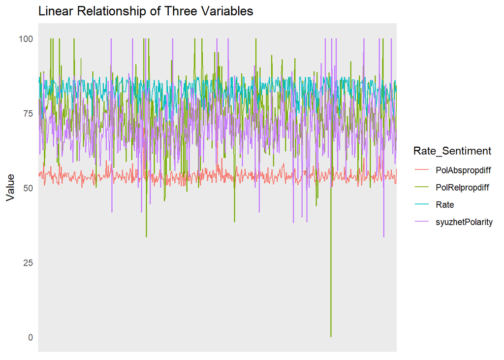

```r
ggplot(data_long, aes(x = doc_id, y = value, color = Rate_Sentiment,group = Rate_Sentiment)) +
  geom_line() +
  labs(title = "Linear Relationship of Three Variables",
       x = "X", y = "Value") +
  theme_minimal()+
  theme(
    axis.title.x = element_blank(),  # Remove x-axis label
    axis.text.x = element_blank(),   # Remove x-axis tick labels
    axis.ticks.x = element_blank()   # Remove x-axis tick marks
  )
```

Plot the graph but this time by region

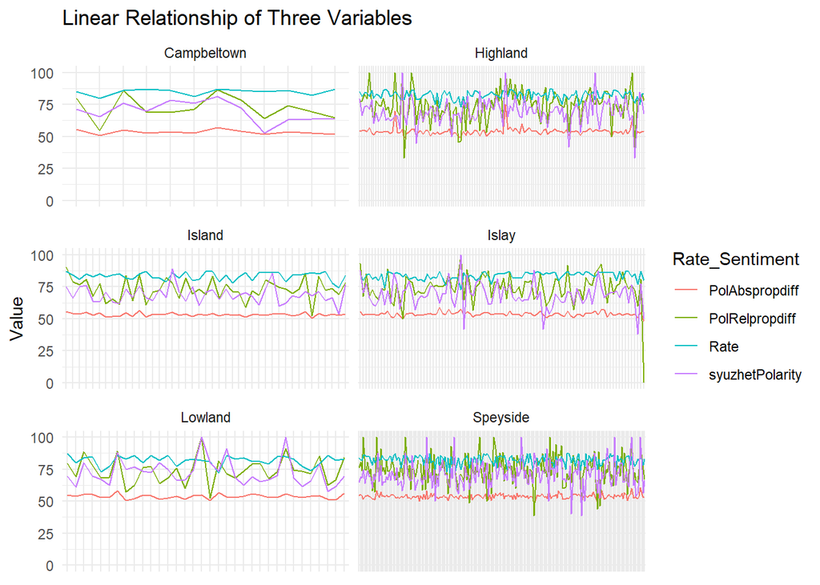

```r
ggplot(data_long, aes(x = doc_id, y = value, color = Rate_Sentiment,group = Rate_Sentiment)) +
  facet_wrap(~Region, scales = "free_x", ncol=2)+
  geom_line() +
  labs(title = "Linear Relationship of Three Variables",
       x = "X", y = "Value") +
  theme_minimal()+
  theme(
    axis.title.x = element_blank(),  # Remove x-axis label
    axis.text.x = element_blank(),   # Remove x-axis tick labels
    axis.ticks.x = element_blank()   # Remove x-axis tick marks
  )
```

## Final Discussion

Which method do you think is more accurate or better better reflect the rate given to the bottle ?